# R for data visualisation

Matt Green

## Bullets

- Content authored with markdown
- Output from executable code

## Basic Plotting

```r
library(dataviz)
library(ggplot2)
library(magrittr)
library(dplyr)
require(papaja)
```

Examine data

```r
data_ala
```

```
## # A tibble: 273 × 3
##    Participant Valence    RT
##          <dbl> <fct>   <dbl>
##  1           1 Happy   0.871
##  2           1 Neutral 0.880
##  3           1 Sad     0.849
##  4           2 Happy   0.891
##  5           2 Neutral 0.925
##  6           2 Sad     0.958
##  7           3 Happy   0.588
##  8           3 Neutral 0.682
##  9           3 Sad     0.828
## 10           4 Happy   0.804
## # ℹ 263 more rows
```

- Use the column names to specify what goes on the `y` axis and what goes on the `x` axis.
- Use `stat_summary` to say that we don’t want to plot the raw data, we want a summary statistic instead.
- Use `geom` to say that we want a bar chart, and `fun` to say that we want the mean (as opposed to the median, say).

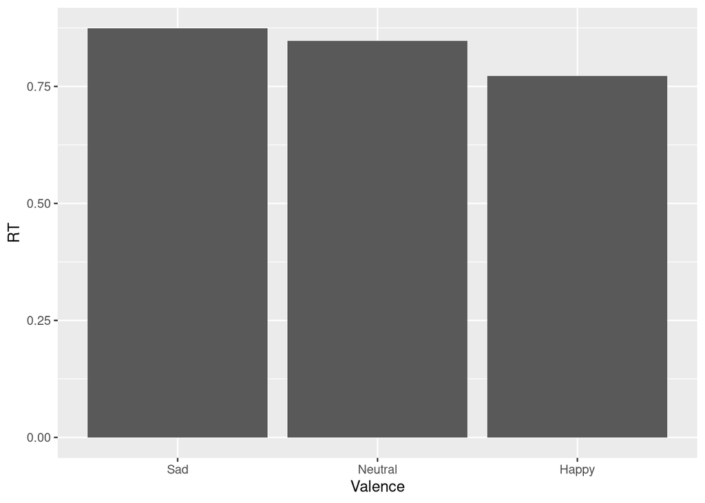

```r
ggplot(data_ala, aes(y=RT, x=Valence))+
  stat_summary(geom="bar", fun="mean")
```

We can add error bars

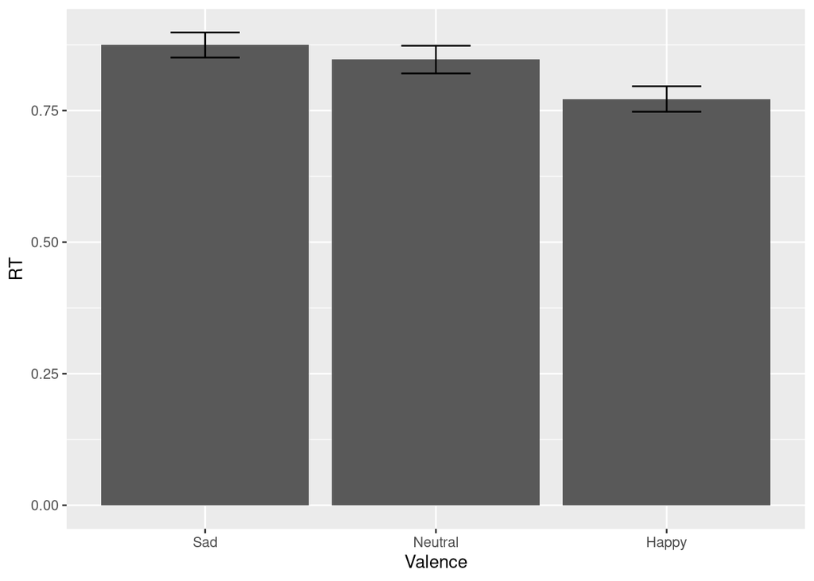

```r
ggplot(data_ala, aes(y=RT, x=Valence))+
  stat_summary(geom="bar", fun="mean")+
  stat_summary(geom='errorbar', width=0.3, fun.data = mean_cl_normal, fun.args=list(conf.int=.95))
```

We can use colour to distinguish the levels of Valence.

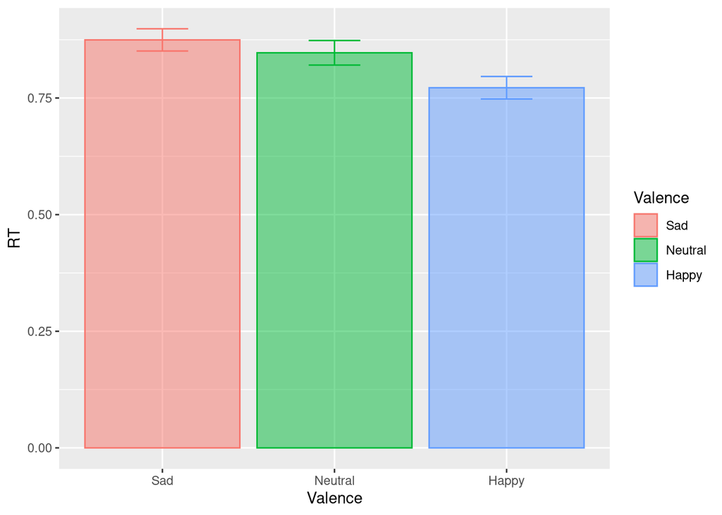

```r
ggplot(data_ala, aes(y=RT, x=Valence, colour=Valence, fill=Valence))+
  stat_summary(geom="bar", fun="mean", alpha=0.5)+
  stat_summary(geom='errorbar', width=0.3, fun.data = mean_cl_normal,
               fun.args=list(conf.int=.95), show.legend = F)
```

Let’s imagine that we had data on the age of the participants: Younger vs Older

```r
data_ala_age <- data_ala %>%
  mutate(Age=ifelse(Participant %% 2, "Older", "Younger"))
```

Let’s imagine that younger people were quicker to respond.

```r
set.seed(1)
data_ala_age <- data_ala_age %>%
  mutate(RT.adjustment=runif(n=nrow(data_ala_age), min=0, max=0.25)) %>%
  mutate(RT=ifelse(Age=="Younger", RT-RT.adjustment, RT))
```

Let’s separate out the two groups of Age

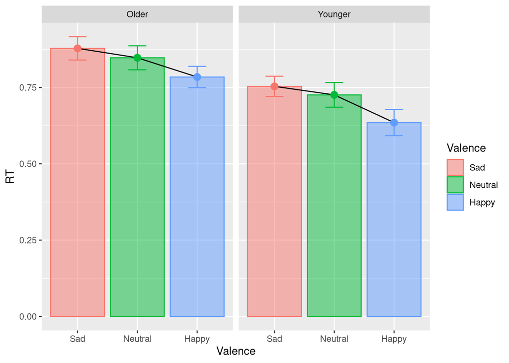

```r
ggplot(data_ala_age, aes(y=RT, x=Valence, colour=Valence, fill=Valence))+
  stat_summary(geom="bar", fun="mean", alpha=0.5)+
  stat_summary(geom="line", fun="mean", aes(group=1), colour="black")+
  stat_summary(geom='errorbar', width=0.3, fun.data = mean_cl_normal,
               fun.args=list(conf.int=.95), show.legend = F)+
  stat_summary(geom='point', fun="mean", size=3, show.legend = F)+
  facet_grid(~Age)
```

Let’s change the theme. This one is `theme_apa()` which is supposed to be APA-compliant. It comes from a package called `papaja`

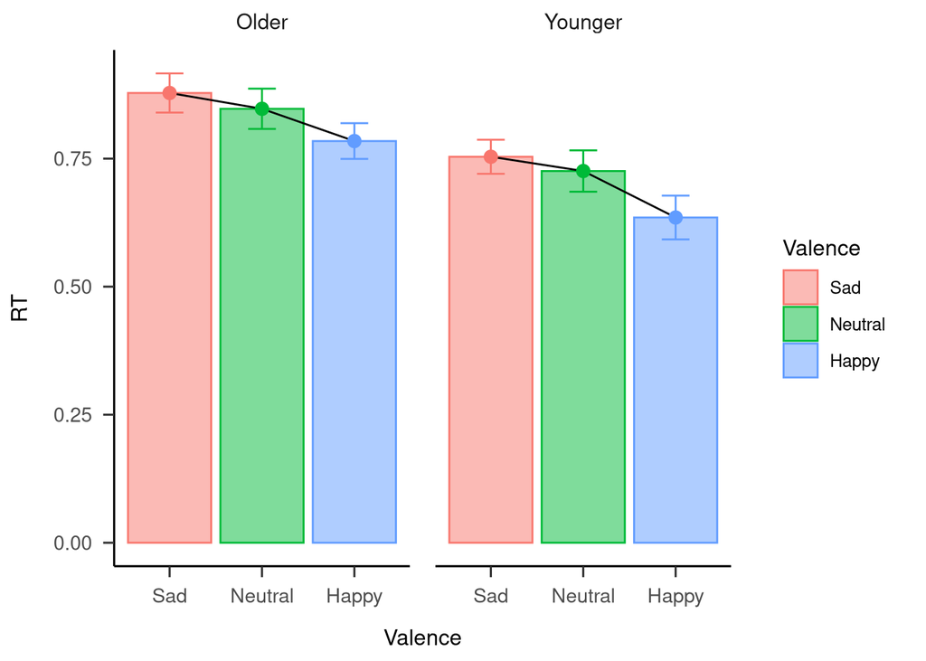

```r
ggplot(data_ala_age, aes(y=RT, x=Valence, colour=Valence, fill=Valence))+
  stat_summary(geom="bar", fun="mean", alpha=0.5)+
  stat_summary(geom="line", fun="mean", aes(group=1), colour="black")+
  stat_summary(geom='errorbar', width=0.3, fun.data = mean_cl_normal,
               fun.args=list(conf.int=.95), show.legend = F)+
  stat_summary(geom='point', fun="mean", size=3, show.legend = F)+
  facet_grid(~Age)+
  theme_apa()
```

Let’s add raw data points

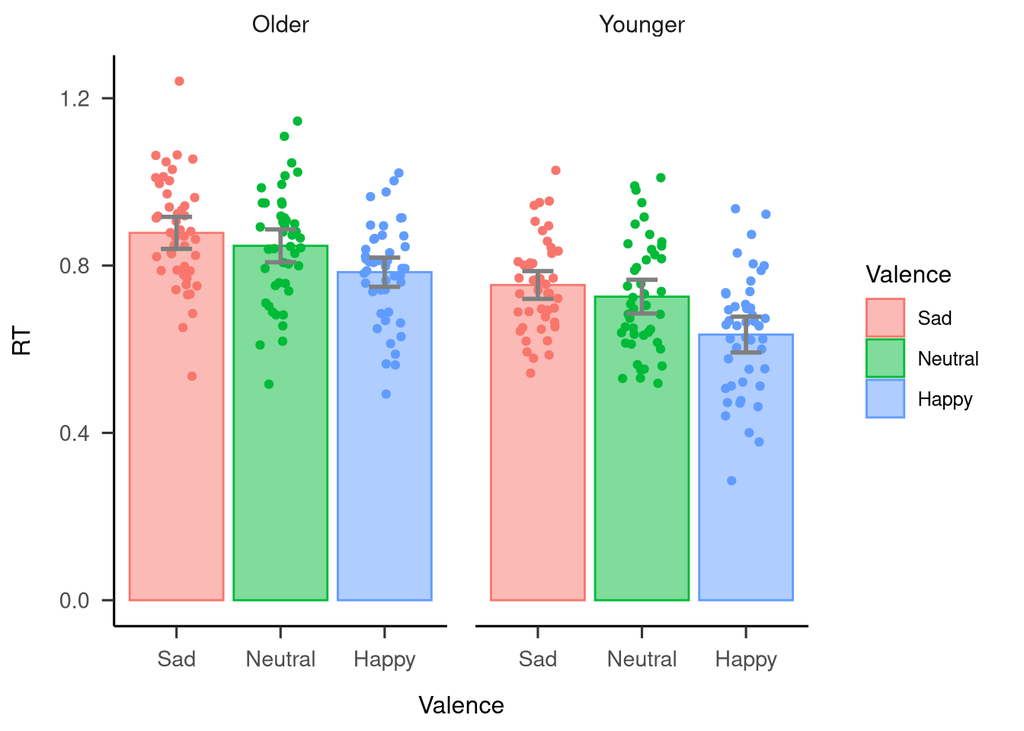

```r
ggplot(data_ala_age, aes(y=RT, x=Valence, colour=Valence, fill=Valence))+
  geom_jitter(width=0.2, height=0, show.legend = F)+
  stat_summary(geom="bar", fun="mean", alpha=0.5)+
  #stat_summary(geom="line", fun="mean", aes(group=1), colour="black")+
  stat_summary(geom='errorbar', width=0.3, fun.data = mean_cl_normal,
               fun.args=list(conf.int=.95), show.legend = F, lwd=1, color='grey50')+
  #stat_summary(geom='point', fun="mean", size=3, show.legend = F)+
  facet_grid(~Age)+
  theme_apa()
```

There are other ways to represent the distribution of raw data points together with summary statistics.

In a violin plot, the violin is widest where the distribution peaks. The code is simple.

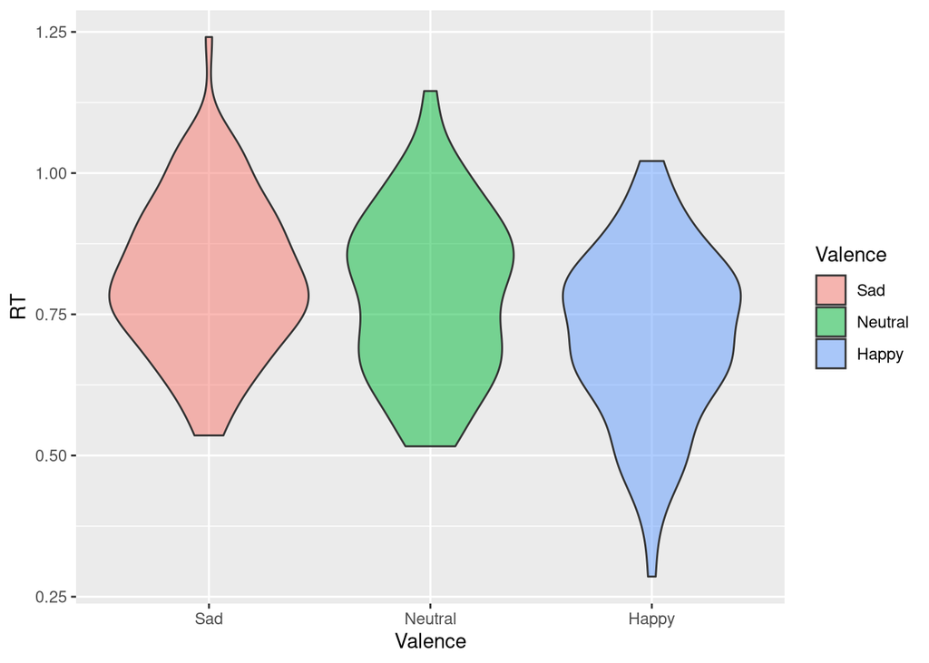

```r
ggplot(data_ala_age, aes(y=RT, x=Valence, fill=Valence))+
  geom_violin(alpha=0.5)
```

We can add raw data, among other things (like a boxplot)

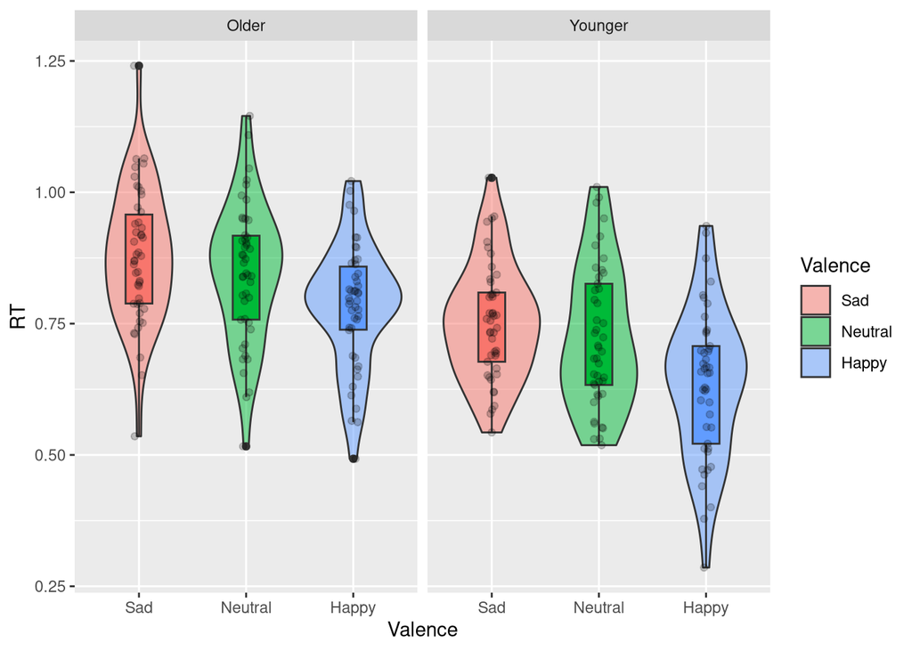

```r
ggplot(data_ala_age, aes(y=RT, x=Valence, fill=Valence))+
  geom_violin(alpha=0.5)+
  geom_boxplot(width=0.25, fatten=0, show.legend = F)+
  geom_jitter(width=0.05, height=0, alpha=0.2, show.legend = F)+
  facet_grid(~Age)
```

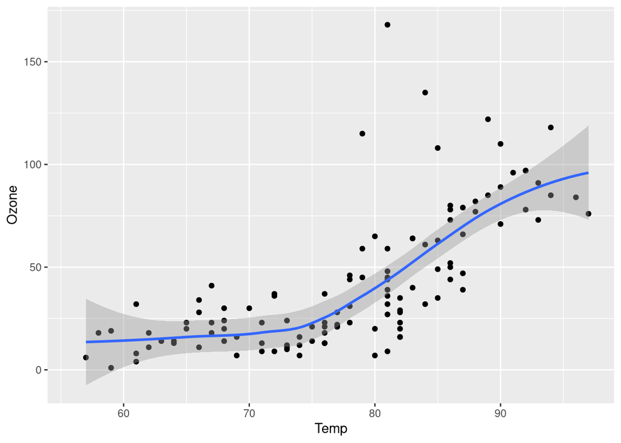

```r
library(ggplot2)
ggplot(airquality, aes(Temp, Ozone)) +
  geom_point() +
  geom_smooth(method = "loess")
```

## Excercises

1. How did we add colour? What additional code did we have to include?
2. What element of a `ggplot` plots separate facets?